# hw-5

Hector He

5/15/2022

```r
pokemon <- read.csv('~/Desktop/Spring 2022/PSTAT 131/homework/homework-5/data/Pokemon.csv')
library(tidymodels)
library(tidyverse)
library(readr)
library(dplyr)
head(pokemon, n = 8)
```

```
##   X.                      Name Type.1 Type.2 Total HP Attack Defense Sp..Atk
## 1  1                 Bulbasaur  Grass Poison   318 45     49      49      65
## 2  2                   Ivysaur  Grass Poison   405 60     62      63      80
## 3  3                  Venusaur  Grass Poison   525 80     82      83     100
## 4  3     VenusaurMega Venusaur  Grass Poison   625 80    100     123     122
## 5  4                Charmander   Fire          309 39     52      43      60
## 6  5                Charmeleon   Fire          405 58     64      58      80
## 7  6                 Charizard   Fire Flying   534 78     84      78     109
## 8  6 CharizardMega Charizard X   Fire Dragon   634 78    130     111     130
##   Sp..Def Speed Generation Legendary
## 1      65    45          1     False
## 2      80    60          1     False
## 3     100    80          1     False
## 4     120    80          1     False
## 5      50    65          1     False
## 6      65    80          1     False
## 7      85   100          1     False
## 8      85   100          1     False
```

Exercise 1 Install and load the janitor package. Use its clean_names() function on the Pokémon data, and save the results to work with for the rest of the assignment. What happened to the data? Why do you think clean_names() is useful?

```r
library(janitor)
pokemon <- clean_names(pokemon)
head(pokemon)
```

```
##   x                  name type_1 type_2 total hp attack defense sp_atk sp_def
## 1 1             Bulbasaur  Grass Poison   318 45     49      49     65     65
## 2 2               Ivysaur  Grass Poison   405 60     62      63     80     80
## 3 3              Venusaur  Grass Poison   525 80     82      83    100    100
## 4 3 VenusaurMega Venusaur  Grass Poison   625 80    100     123    122    120
## 5 4            Charmander   Fire          309 39     52      43     60     50
## 6 5            Charmeleon   Fire          405 58     64      58     80     65
##   speed generation legendary
## 1    45          1     False
## 2    60          1     False
## 3    80          1     False
## 4    80          1     False
## 5    65          1     False
## 6    80          1     False
```

column names are changed, now only including lower case letters and "_" symbols, which are easier to access

Exercise 2 Using the entire data set, create a bar chart of the outcome variable, type_1. How many classes of the outcome are there? Are there any Pokémon types with very few Pokémon? If so, which ones?

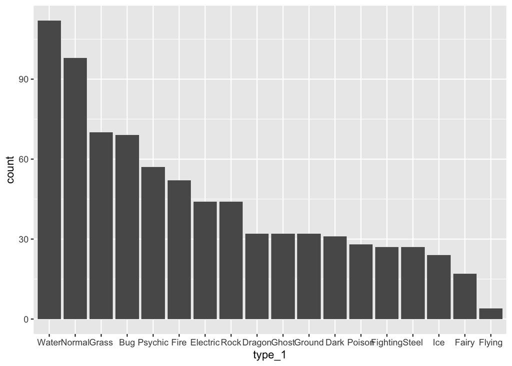

```r
#ggplot(data = pokemon, aes(x = type_1)) + geom_bar()
ggplot(data = pokemon, aes(x = reorder(factor(type_1), type_1, function(x)-length(x)))) + geom_bar() + labs(x = 'type_1')
```

Type 1 Poison, Fighting, Steel, Ice, Fairy, Flying have less than 30 counts, especially Type 1 Flying has less than 10 counts

```r
pokemon <- filter(pokemon, type_1=='Bug'|type_1=='Fire'|type_1=='Grass'|type_1=='Normal'|type_1=='Water'|type_1=='Psychic')
head(pokemon, n = 15)
```

```
##     x                      name type_1 type_2 total hp attack defense sp_atk
## 1   1                 Bulbasaur  Grass Poison   318 45     49      49     65
## 2   2                   Ivysaur  Grass Poison   405 60     62      63     80
## 3   3                  Venusaur  Grass Poison   525 80     82      83    100
## 4   3     VenusaurMega Venusaur  Grass Poison   625 80    100     123    122
## 5   4                Charmander   Fire          309 39     52      43     60
## 6   5                Charmeleon   Fire          405 58     64      58     80
## 7   6                 Charizard   Fire Flying   534 78     84      78    109
## 8   6 CharizardMega Charizard X   Fire Dragon   634 78    130     111    130
## 9   6 CharizardMega Charizard Y   Fire Flying   634 78    104      78    159
## 10  7                  Squirtle  Water          314 44     48      65     50
## 11  8                 Wartortle  Water          405 59     63      80     65
## 12  9                 Blastoise  Water          530 79     83     100     85
## 13  9   BlastoiseMega Blastoise  Water          630 79    103     120    135
## 14 10                  Caterpie    Bug          195 45     30      35     20
```

[output cut: 17 more lines]

```r
pokemon <- pokemon %>%
  mutate(type_1 = factor(type_1)) %>%
  mutate(legendary = factor(legendary))
tail(pokemon, n=10)
```

```
##       x                name  type_1 type_2 total  hp attack defense sp_atk
## 449 673              Gogoat   Grass          531 123    100      62     97
## 450 676             Furfrou  Normal          472  75     80      60     65
## 451 677              Espurr Psychic          355  62     48      54     63
## 452 678        MeowsticMale Psychic          466  74     48      76     83
## 453 678      MeowsticFemale Psychic          466  74     48      76     83
## 454 692           Clauncher   Water          330  50     53      62     58
## 455 693           Clawitzer   Water          500  71     73      88    120
## 456 720 HoopaHoopa Confined Psychic  Ghost   600  80    110      60    150
## 457 720  HoopaHoopa Unbound Psychic   Dark   680  80    160      60    170
## 458 721           Volcanion    Fire  Water   600  80    110     120    130
##     sp_def speed generation legendary
## 449     81    68          6     False
## 450     90   102          6     False
## 451     60    68          6     False
## 452     81   104          6     False
## 453     81   104          6     False
## 454     63    44          6     False
## 455     89    59          6     False
## 456    130    70          6      True
## 457    130    80          6      True
## 458     90    70          6      True
```

Exercise 3 Perform an initial split of the data. Stratify by the outcome variable. You can choose a proportion to use. Verify that your training and test sets have the desired number of observations. Next, use v-fold cross-validation on the training set. Use 5 folds.

```r
set.seed(2000)
pokemon_split <- initial_split(pokemon, prop = 0.75, strata = type_1)
pokemon_test <- testing(pokemon_split)
pokemon_train <- training(pokemon_split)
```

```r
dim(pokemon_train)
```

```
## [1] 341  13
```

```r
dim(pokemon_test)
```

```
## [1] 117  13
```

```r
pokemon_folds <- vfold_cv(pokemon_train, v = 5, strata = type_1)
pokemon_folds
```

```
## #  5-fold cross-validation using stratification
## # A tibble: 5 × 2
##   splits           id
##   <list>           <chr>
## 1 <split [270/71]> Fold1
## 2 <split [271/70]> Fold2
## 3 <split [273/68]> Fold3
## 4 <split [274/67]> Fold4
## 5 <split [276/65]> Fold5
```

Exercise 4 Set up a recipe to predict type_1 with legendary, generation, sp_atk, attack, speed, defense, hp, and sp_def.

```r
pokemon_recipe <- recipe(type_1 ~ legendary+generation+sp_atk+attack+speed+defense+hp+sp_def, data = pokemon_train) %>%
  step_dummy(c(legendary, generation)) %>%
  step_center(all_predictors()) %>%
  step_scale(all_predictors())
```

Exercise 5

```r
library(glmnet)
pokemon_tuned <-
  multinom_reg(penalty = tune(), mixture = tune()) %>%
  set_mode("classification") %>%
  set_engine("glmnet")
```

```r
pokemon_wkflow_tuning <- workflow() %>%
  add_recipe(pokemon_recipe) %>%
  add_model(pokemon_tuned)
```

Exercise 6

```r
pokemon_grid <- grid_regular(penalty(range = c(-5, 5)), mixture(range = c(0, 1)), levels = 10)
pokemon_grid
```

```
## # A tibble: 100 × 2
##          penalty mixture
##            <dbl>   <dbl>
##  1      0.00001        0
##  2      0.000129       0
##  3      0.00167        0
##  4      0.0215         0
##  5      0.278          0
##  6      3.59           0
##  7     46.4            0
##  8    599.             0
##  9   7743.             0
## 10 100000              0
## # … with 90 more rows
```

There will be 10*10 = 100 models fitted into the folded data

Exercise 7

```r
pokemon_tune_res <- tune_grid(pokemon_wkflow_tuning, resamples = pokemon_folds, grid = pokemon_grid)
```

[output not shown]

[output not shown]

[output not shown]

[output not shown]

[output not shown]

```r
pokemon_tune_res
```

```
## # Tuning results
## # 5-fold cross-validation using stratification
## # A tibble: 5 × 4
##   splits           id    .metrics           .notes
##   <list>           <chr> <list>             <list>
## 1 <split [270/71]> Fold1 <tibble [200 × 6]> <tibble [1 × 3]>
## 2 <split [271/70]> Fold2 <tibble [200 × 6]> <tibble [1 × 3]>
## 3 <split [273/68]> Fold3 <tibble [200 × 6]> <tibble [1 × 3]>
## 4 <split [274/67]> Fold4 <tibble [200 × 6]> <tibble [1 × 3]>
## 5 <split [276/65]> Fold5 <tibble [200 × 6]> <tibble [1 × 3]>
##
## There were issues with some computations:
##
##   - Warning(s) x5: The following variables are not factor vectors and will be ignore...
##
## Use `collect_notes(object)` for more information.
```

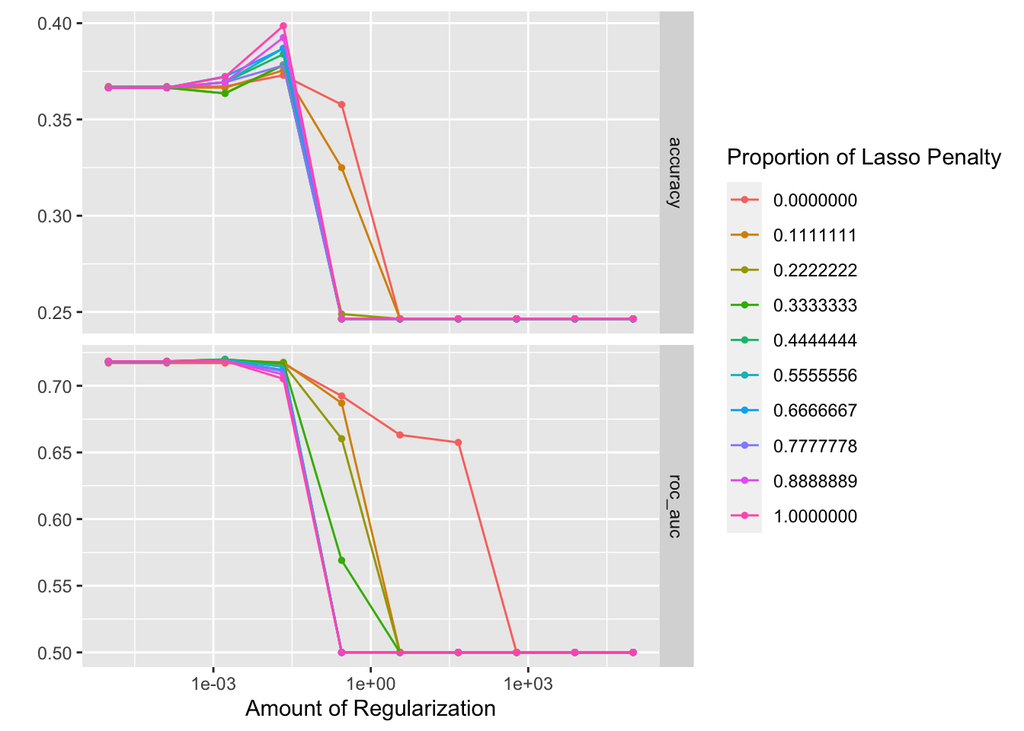

```r
autoplot(pokemon_tune_res)
```

```r
collect_metrics(pokemon_tune_res)
```

```
## # A tibble: 200 × 8
##     penalty mixture .metric  .estimator  mean     n std_err .config
##       <dbl>   <dbl> <chr>    <chr>      <dbl> <int>   <dbl> <chr>
##  1 0.00001        0 accuracy multiclass 0.367     5  0.0266 Preprocessor1_Model…
##  2 0.00001        0 roc_auc  hand_till  0.717     5  0.0118 Preprocessor1_Model…
##  3 0.000129       0 accuracy multiclass 0.367     5  0.0266 Preprocessor1_Model…
##  4 0.000129       0 roc_auc  hand_till  0.717     5  0.0118 Preprocessor1_Model…
##  5 0.00167        0 accuracy multiclass 0.367     5  0.0266 Preprocessor1_Model…
##  6 0.00167        0 roc_auc  hand_till  0.717     5  0.0118 Preprocessor1_Model…
##  7 0.0215         0 accuracy multiclass 0.373     5  0.0250 Preprocessor1_Model…
##  8 0.0215         0 roc_auc  hand_till  0.716     5  0.0110 Preprocessor1_Model…
##  9 0.278          0 accuracy multiclass 0.358     5  0.0178 Preprocessor1_Model…
## 10 0.278          0 roc_auc  hand_till  0.692     5  0.0113 Preprocessor1_Model…
## # … with 190 more rows
```

```r
pokemon_best_tuned <- select_best(pokemon_tune_res, metric = "roc_auc")
pokemon_best_tuned
```

```
## # A tibble: 1 × 3
##   penalty mixture .config
##     <dbl>   <dbl> <chr>
## 1 0.00167   0.444 Preprocessor1_Model043
```

```r
pokemon_final <- finalize_workflow(pokemon_wkflow_tuning, pokemon_best_tuned)
pokemon_final_fit <- fit(pokemon_final, data = pokemon_train)
```

Exercise 8

```r
augment(pokemon_final_fit, new_data = pokemon_test) %>%
  roc_auc(type_1, .pred_Bug:.pred_Water)
```

```
## # A tibble: 1 × 3
##   .metric .estimator .estimate
##   <chr>   <chr>          <dbl>
## 1 roc_auc hand_till      0.728
```

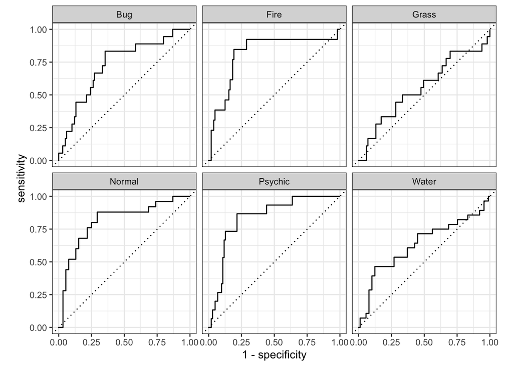

```r
augment(pokemon_final_fit, new_data = pokemon_test) %>%
  roc_curve(truth = type_1, estimate = .pred_Bug:.pred_Water) %>%
  autoplot()
```